# Machine Learning to Predict Correct and Incorrect Barbell Lifts

========================================================

## SYNOPSIS

The objective of this report is to predict correctness (and respectively incorrectness) of barbell lifts.

========================================================

## PART A. DATA PROCESSING

### 1 Install and load packages

Step 1 installs and loads the required packages.

```r
##install.packages("caret")
library(caret)
```

### 2 Load Data

This step loads the training dataset (“train”) and the testing dataset (“test”).

```r
train <- read.csv("R:/Online Courses/John Hopkins University - Data Science (Spring 2014)/Data Science Specialization/08_Practical_Machine_Learning/Course_Project/pml-training.csv")
test <- read.csv("R:/Online Courses/John Hopkins University - Data Science (Spring 2014)/Data Science Specialization/08_Practical_Machine_Learning/Course_Project/pml-testing.csv")
```

### 3 Create Random Forest Predictor

As described in the lecture notes and discussed widely within the respective forums, the rainforest method seems to be the most promising method and, thus, is used first in order to receive a score against which further models can be compared.

My rainforest model predicts the variable “classe” which is a categorical variable (i.e., a factor variable) with five potential values: A, B, C, D, and E.

```r
levels(train$classe)
```

```
## [1] "A" "B" "C" "D" "E"
```

```r
# Create Model Random Forest
modRf <- train(classe ~
                  roll_belt +
                  pitch_belt +
                  yaw_belt +
                  total_accel_belt +
                  gyros_belt_x +
                  gyros_belt_y +
                  gyros_belt_z +
                  accel_belt_x +
                  accel_belt_y +
                  accel_belt_z +
                  magnet_belt_x +
                  magnet_belt_y +
                  magnet_belt_z +
                  roll_arm +
                  pitch_arm +
                  yaw_arm +
                  total_accel_arm +
                  gyros_arm_x +
                  gyros_arm_y +
                  gyros_arm_z +
                  accel_arm_x +
                  accel_arm_y +
                  accel_arm_z +
                  magnet_arm_x +
                  magnet_arm_y +
                  magnet_arm_z +
                  roll_dumbbell +
                  pitch_dumbbell +
                  yaw_dumbbell,
                method="rf", data=train)
```

Since the computation of my Rainforest model took some time, I want to check the time I required and then I output the results:

### 4 Detailed Information about the Created Model

```r
modRf$times
```

```
## $everything
##    user  system elapsed
## 2890.51   19.61 2911.88
##
## $final
##    user  system elapsed
##   31.21    0.23   31.49
##
## $prediction
## [1] NA NA NA
```

```r
modRf
```

```
## Random Forest
##
## 19622 samples
##   159 predictors
##     5 classes: 'A', 'B', 'C', 'D', 'E'
##
## No pre-processing
## Resampling: Bootstrapped (25 reps)
##
## Summary of sample sizes: 19622, 19622, 19622, 19622, 19622, 19622, ...
##
## Resampling results across tuning parameters:
##
##   mtry  Accuracy  Kappa  Accuracy SD  Kappa SD
##   2     1         1      0.002        0.002
##   20    1         1      0.002        0.002
##   30    1         1      0.003        0.003
##
## Accuracy was used to select the optimal model using  the largest value.
## The final value used for the model was mtry = 2.
```

The following uses the computed model on the training data (once again) and outputs detailed data and plots the predictions against their actual value.

```r
predCheck <- predict(modRf, train)
table(predCheck, train$classe) ## Result: 100% correct prediction!
```

```
##
## predCheck    A    B    C    D    E
##         A 5580    0    0    0    0
##         B    0 3797    0    0    0
##         C    0    0 3422    0    0
##         D    0    0    0 3216    0
##         E    0    0    0    0 3607
```

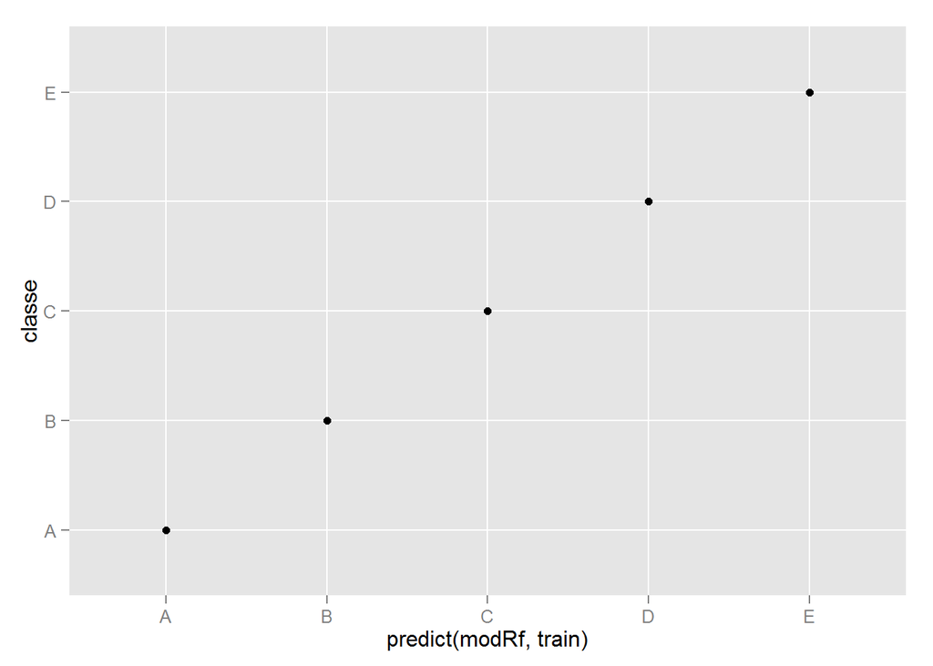

```r
qplot(predict(modRf, train), classe, data=train)
```

## PART C. Prediction of Values from test dataset

### 5 Prediction of test$classe

As the output from the previous chunck indicates, all values are predicted correctly.

Consequently, I decided to adapt my computed rainforest model to the test-dataset. The following chunk creates the output which I also entered for this assignment as submission.

```r
pred <- predict(modRf, test)
pred
```

```
##  [1] B A B A A E D B A A B C B A E E A B B B
## Levels: A B C D E
```

## PART D. Additionally Required Tasks for Assigment

### 6 Cross Validation

For completeness I test the same approach with cross-validation. Therefore, the training set is splitted into two subsets: trainSubset and testSubset. Due to the very large number of elements in the “real” training dataset (19622 observations of 160 variables), I use 90% for for trainSubset and 10% for testSubset.

```r
set.seed(10)
dataPartition = createDataPartition(train$classe, p=0.9, list=FALSE)
trainSubset = train[dataPartition,]
testSubset = train[-dataPartition,]
```

As previously, I now create the rainforest model:

```r
# Create Model of Subset with Random Forest
modRfSubset <- train(classe ~
                  roll_belt +
                  pitch_belt +
                  yaw_belt +
                  total_accel_belt +
                  gyros_belt_x +
                  gyros_belt_y +
                  gyros_belt_z +
                  accel_belt_x +
                  accel_belt_y +
                  accel_belt_z +
                  magnet_belt_x +
                  magnet_belt_y +
                  magnet_belt_z +
                  roll_arm +
                  pitch_arm +
                  yaw_arm +
                  total_accel_arm +
                  gyros_arm_x +
                  gyros_arm_y +
                  gyros_arm_z +
                  accel_arm_x +
                  accel_arm_y +
                  accel_arm_z +
                  magnet_arm_x +
                  magnet_arm_y +
                  magnet_arm_z +
                  roll_dumbbell +
                  pitch_dumbbell +
                  yaw_dumbbell,
                method="rf", data=trainSubset)
## Show information about the subset model:
modRfSubset$times
```

```
## $everything
##    user  system elapsed
## 2570.14   16.91 2588.58
##
## $final
##    user  system elapsed
##   27.75    0.18   27.94
##
## $prediction
## [1] NA NA NA
```

```r
modRfSubset
```

```
## Random Forest
##
## 17662 samples
##   159 predictors
##     5 classes: 'A', 'B', 'C', 'D', 'E'
##
## No pre-processing
## Resampling: Bootstrapped (25 reps)
##
## Summary of sample sizes: 17662, 17662, 17662, 17662, 17662, 17662, ...
##
## Resampling results across tuning parameters:
##
##   mtry  Accuracy  Kappa  Accuracy SD  Kappa SD
##   2     1         1      0.002        0.002
##   20    1         1      0.003        0.003
##   30    1         1      0.003        0.004
##
## Accuracy was used to select the optimal model using  the largest value.
## The final value used for the model was mtry = 2.
```

```r
predCheckSubset <- predict(modRfSubset, testSubset)
table(predCheckSubset, testSubset$classe)
```

```
##
## predCheckSubset   A   B   C   D   E
##               A 555   7   1   0   0
##               B   1 368   5   0   3
##               C   2   4 336   2   1
##               D   0   0   0 319   2
##               E   0   0   0   0 354
```

```r
accuracyRfSubset_i = (testSubset$classe == predCheckSubset)
accuracyRfSubset = length(accuracyRfSubset_i[accuracyRfSubset_i==TRUE]) / length(accuracyRfSubset_i)
accuracyRfSubset
```

```
## [1] 0.9857
```

### 7 Estimation of Out of Sample Error

In this step I estimate the out of sample error of modRf. I assume that the sample error of modRFSubset is approximately the sample error of modRf, because modRFSubset contains 90% of the elements of modRf and I cannot compute the out of sample error for modRf exactly.

```r
oos_error <- 1-accuracyRfSubset
oos_error
```

```
## [1] 0.01429
```

The estimated out of sample error is approximately 1.429%.

======================================================== (End of report)